# Лабораторная работа № 4

Основы интерфейса взаимодействия пользователя с системой Unix на уровне командной строки

Шулуужук Айраана Вячеславовна НПИбд-02-22

Российский университет дружбы народов, Москва, Россия

27 февраля 2023

## Докладчик

- Шулуужук Айраана Вячеславовна
- НПИбд-02-22
- 1132221890
- Российский университет дружбы народов

# Цели и задачи

Приобретение практических навыков взаимодействия пользователя с системой посредством командной строки

# Выполнение лабораторной работы

## Команда pwd

Определим полное имя домашнего каталога. Используем команду pwd.

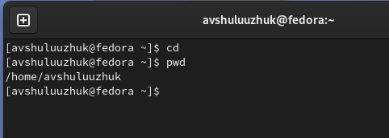

полное имя домашнего каталога

## Команда ls

Перейдем в каталог /tmp. Выводим на экран сожержимое каталога tmp, используя команду ls с различными опциями.

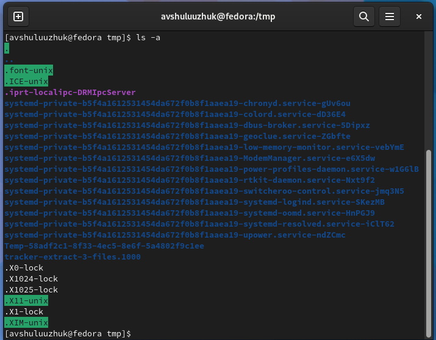

коаманда ls -a

## Команда ls

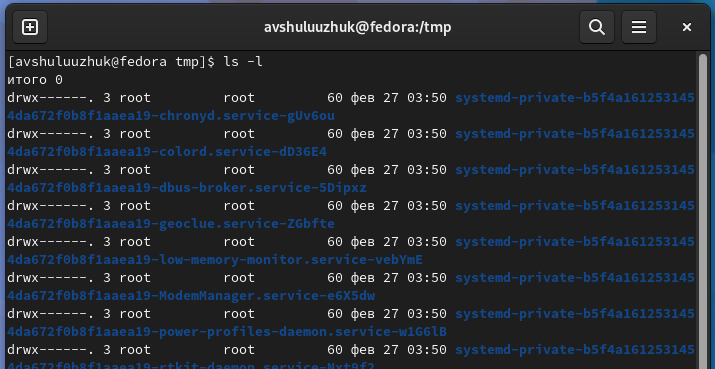

команда ls -l

## Команда ls

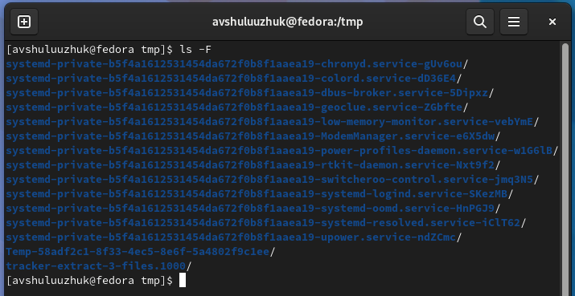

команда ls -F

## Команда ls

Определим, есть ли в каталоге /var/spool подкаталог с именем cron. В результате мы находим, что нет файла с именем cron

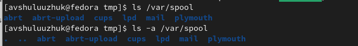

просмотр файлов в каталоге /var/spool

## Команда ls

Выводим на экран его содержимое и определяем кто является владельцем файлов и каталогов

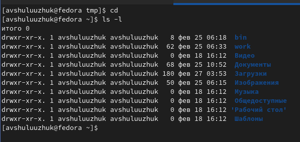

домашний каталог

## Команда mkdir

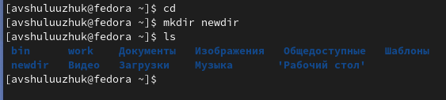

создание каталога newdir

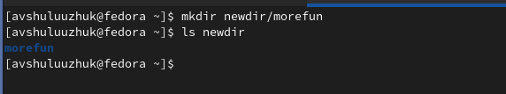

создание каталога morefun в каталоге newdir

## Команда mkdir

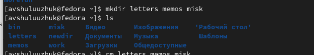

создание каталогов letters memos misk

## Команда rmdir

Затем удаляем эти каталоги одной командой rmdir letters memos misk и проверим удалились ли они

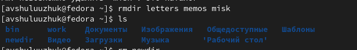

удаление каталогов letters memos misk

## Команда rm

Удаляем каталог /newdir/morefun командой rm с опцией -r. Проверяем удаление каталога

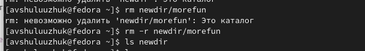

удаление /newdir/morefun

## Команда man ls

С помощью команды man ls определяем, что для просмотра содержимого каталога и подкаталогов, входящих в него, нужно использовать опцию -R

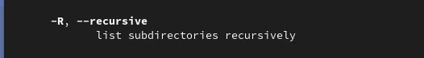

описание опции -R

## Команда man ls

С помощью команды man ls опредеяем набор опций команды, позволяющий отсортировать по времени последнего изменения список содержимого каталога. Это опции: -с -lt

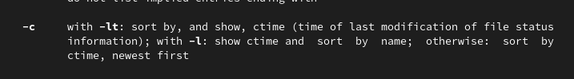

описание опций -с -lt

## Команда man cd

Команда cd испоьзуется для перемещения по файловой системе

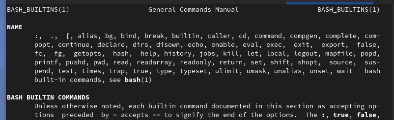

man cd

## Команда man pwd

Для определения абсолютного пути к текущему каталогу используется команда pwd

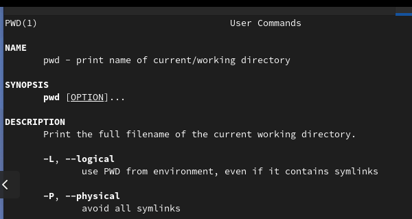

man pwd

## Команда man mkdir

Команда mkdir используется для создания каталогов

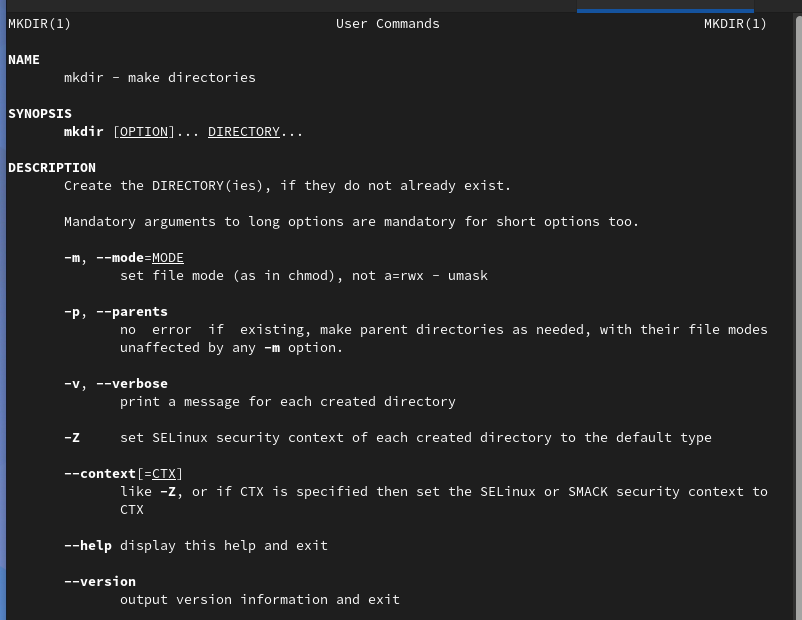

man mkdir

## Команда man rmdir

Команда rmdir используется для удаления пустых каталогов

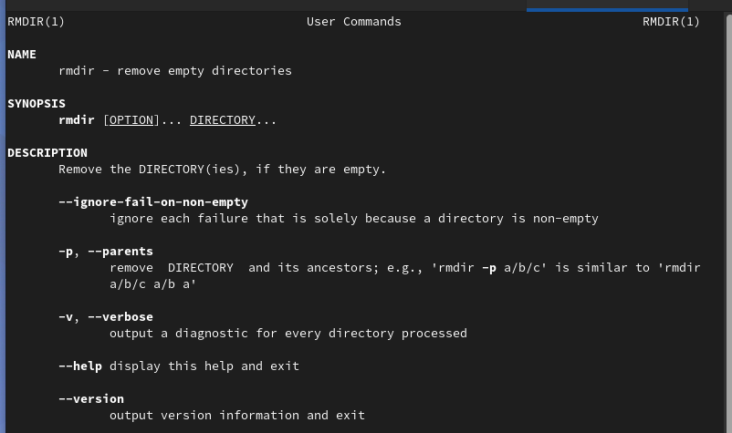

man rmdir

## Команда man rm

Команда rm используется для удаления файлов и каталогов

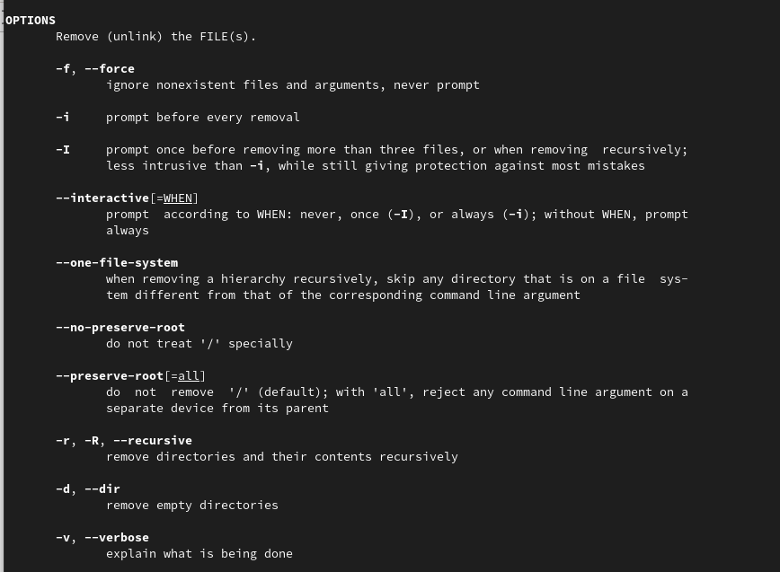

man rm

## Команда history

Используя информацию, полученную при помощи команды history, выполняем модификацию команд mcdir, rmdir

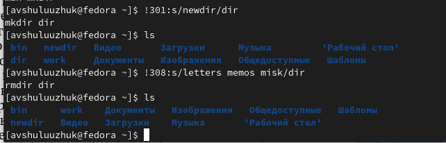

модификация команд mcdir и rmdir

# Выводы

В ходе выполнения лабораторной работы были приобретены практические навыки взаимодействия пользователя с системой посредством командной строки. Был составлен отчет о выполнении лаборатороной работы